# Final - Optimization and Simulation

Yetkineser

3/25/2018

# Questions

## 1.A -

Fancy Skateboard Manufacturing produces two popular skateboards: the Red and the Blue. In the coming week, the manufacturer wants to produce at least 600 skateboards and wants to ensure the number of Reds produced does not exceed the number of Blues by more than 300. Each Red produced and sold results in a profit of $80 while each Blue results in a profit of $30. Both skateboards use the same mechanical equipment; however, they require different amount of wood for the appearance. Each Red???s trim requires 2 pounds of wood and 3 hours of production time while each Blue requires 1 pound of wood and 4 hours of production time. Fancy has limited amount of wood and labor hours that they can use each week as follows: at most 1200 pounds of wood and 2,800 labor hours. What is the best production schedule?

```r
library(lpSolve)

obj.fun <- c(80, 30)
constr <- matrix(c(2, 1,  # for wood
                   3, 4,   # for hours
                   1, -1),  # red-blue<=300
                 ncol = 2, byrow=TRUE)
constr.dir <- c("<=", "<=", "<=")
rhs <- c(1200, 2800, 300)
#solving model
prod.sol <- lp("max", obj.fun, constr, constr.dir, rhs, compute.sens = TRUE, all.int = TRUE)

# str(prod.sol)
print(prod.sol$solution)
```

```
## [1] 500 200
```

```r
print(prod.sol)
```

```
## Success: the objective function is 46000
```

## 2.A -

A company named Uretici can produce an item on six different machines. The following table summarizes the manufacturing costs associated with producing the items on each machine along with the available capacity on each machine. If the company has received an order for 1,800 items, which machines should be used to minimize cost?

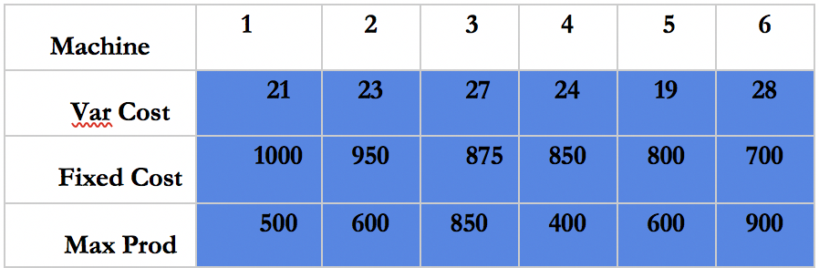

```r
library(knitr)
include_graphics("/Users/yetkineser/Desktop/q2a.png")
```

```r
library(lpSolve)

obj.fun <- c(1000,950,875,850,800,700,
             21,23,27,24,19,28)
constr <- matrix(c(0, 0, 0, 0, 0, 0, 1, 1, 1, 1, 1, 1, # for production of each machine
                   500, 0, 0, 0, 0, 0, -1, 0, 0, 0, 0, 0,   # for 1. machine production limit
                   0, 600, 0, 0, 0, 0, 0, -1, 0, 0, 0, 0,   # for 2. machine production limit
                   0, 0, 850, 0, 0, 0, 0, 0, -1, 0, 0, 0,   # for 3. machine production limit
                   0, 0, 0, 400, 0, 0, 0, 0, 0, -1, 0, 0,   # for 4. machine production limit
                   0, 0, 0, 0, 600, 0, 0, 0, 0, 0, -1, 0,   # for 5. machine production limit
                   0, 0, 0, 0, 0, 900, 0, 0, 0, 0, 0, -1   # for 6. machine production limit
                   ),
                 ncol = 12, byrow=TRUE)
constr.dir <- c("==", ">=", ">=", ">=", ">=", ">=", ">=")
rhs <- c(1800, 0, 0, 0, 0, 0, 0)
#solving model
prod.sol <- lp("min", obj.fun, constr, constr.dir, rhs, compute.sens = TRUE, all.int = TRUE, binary.vec = 1:6)

# str(prod.sol)
print(prod.sol$solution)
```

```
##  [1]   1   1   0   1   1   0 500 600   0 100 600   0
```

```r
print(prod.sol)
```

```
## Success: the objective function is 41700
```

## 3.A -

A publisher has 1500 copies of a popular book on hand and would like to decide whether to do another printing within the next year. The publisher estimates that demand for the book during the upcoming year will be minimum 1250, maximum 5000 and most likely 2500 copies. A production run incurs a fixed cost of $72,000; plus there will be a variable cost of $10 per book printed. Books are sold for $30 per book. Any demand that cannot be met incurs a penalty cost of $2 per book, due to loss of goodwill. Leftover books can be sold to Barnes&Noble for $3 per book. If the publisher decides to print 1000 copies, what is the expected profit?

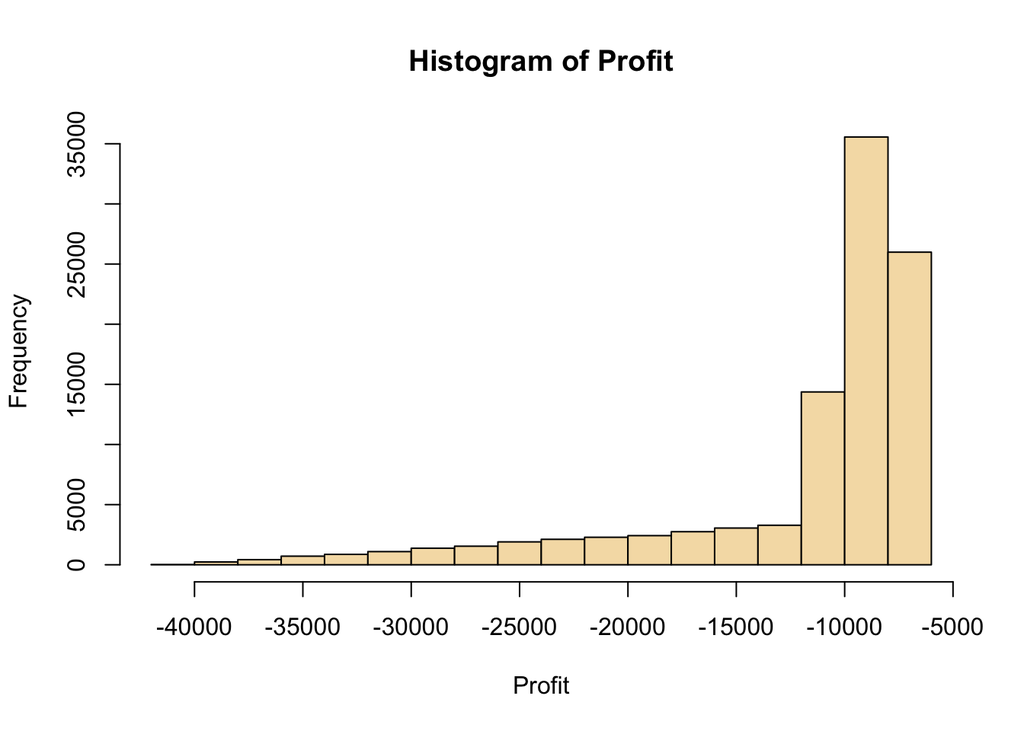

```r
#install.packages("triangle")
library(triangle)

already <- 1500
min <- 1250
max <- 5000
mlikely <- 2500
fixed_cost <- 72000
variable_cost <- 10
book_price <- 30
penalty_cost <- 2
barnes_price <- 3
decided_copies <- 1000

Profit = NULL
cost = NULL
revenue = NULL

for(i in 1:100000) {
  demand <- round(rtriangle(n=1 ,a = min, b = max, c = mlikely))
  cost[i] <- fixed_cost +
    (decided_copies * variable_cost) +  # per book cost
    (max(0,(demand - (already + decided_copies))) * penalty_cost) # loss of goodwill

  revenue[i] <- (min(demand, (already + decided_copies)) * book_price) + # normal sell
  (max(0, ((already + decided_copies)-demand)) * barnes_price) # Barnes&Noble sell

  Profit[i] = revenue[i] - cost[i]

}

hist(Profit,col="wheat")
```

```r
summary(Profit)
```

```
##    Min. 1st Qu.  Median    Mean 3rd Qu.    Max.
##  -40399  -11658   -9204  -11847   -7958   -7000
```

## Q4 -

Of all the cases we read this semester, which case have you found to have the most possible potential for machine learning applications? Please explain your answer thoroughly in one or two paragraphs.

**Answer**

I thought Coca-Cola Enterprises Optimizes Vehicle Routes for Efficient Product Delivery has most potential for machine learning applications.

Because optimize it mathematically takes so many times(try all solutions.). So in paper when they try to solve this problem they use heuristic. But in the future they can find best solution (or more better solution) easily(n) thanks to past data and machine learning.

For example in go (Chinese strategy game) most people thougt machine can not beat pro go player. But thanks to machine learning algorithm machine beat best go player. Also in go there are so many possibilities but machine learn past match and beat best go player.

**Reference** https://www.netflix.com/tr-en/title/80190844